# Lab 4: KNN regression

Write a function `myknn()` to perform KNN regression on a data set with two columns – one for the predictor and one for the response.

Inputs to your function should be:

- `dat` = data.frame with two columns
- `name.x` = name of predictor column
- `name.y` = name of response column
- `k` = the K in KNN

Your function should return `yhat` = vector of predicted $y$ values for each $x$ value in column `name.x`.

The steps below tell how to test `myknn()`.

1. Fit an SLR model on the `advertising` data using `TV` as the predictor and `sales` as the response. Make a scatter plot of the data and the fitted SLR line. Compute the MSE for the SLR model.
   $$MSE = \frac{1}{n} \sum_{i=1}^n (y_i - \hat f(x_i))^2= \frac{1}{n} \sum_{i=1}^n (y_i - \hat y_i)^2$$

```r
library(dplyr)
library(FNN)
advertising <- read.csv("~/Desktop/stat5310/week13/Advertising.csv", row.names=1)
```

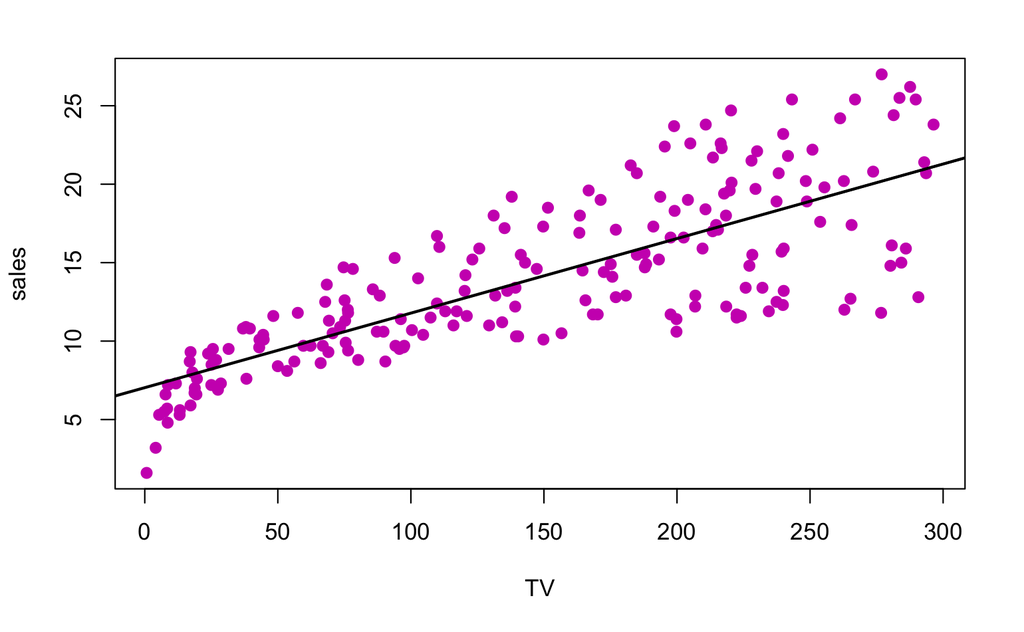

```r
##fit SLR model
TV.mod <- lm(sales~TV, data=advertising)

##make a scatter plot
plot(sales~TV, data=advertising, pch=19, col=6); abline(TV.mod, col=1, lwd=2)
```

```r
##compute MSE for SLR model
MSE <- mean(TV.mod$residuals^2)
MSE
```

```
[1] 10.51265
```

2. Use `myknn()` to fit three KNN models to the same data using $k$ values 3,9, and 27. Compute the MSE for each $k$ value and overlay each of the resulting `yhat` vectors on the scatter plot in a different color. Add a legend.

```r
## write a function

myknn <- function(dat, name.x, name.y, k) {

dat <- dat[order(dat[,name.x]),]

yhat <- NULL

for(i in 1:nrow(dat)){
x0 <- dat[, name.x][i]
dat$d0 <- abs(dat[,name.x] - x0)
yi <- dat %>% arrange(d0) %>% head(k) %>% select(name.y) %>% unlist() %>% mean()
yhat <- c(yhat, yi)


}
return(yhat)

}

##k is 3
yhat_3 <- myknn(advertising, 'TV', 'sales', 3)
yhat_3
```

```
  [1]  3.366667  4.666667  4.666667  5.933333  5.933333  5.900000  5.900000  5.900000  6.066667  6.066667  6.066667  7.966667  7.966667  7.966667  7.733333  6.766667  6.766667  7.066667  7.066667
 [20]  8.300000  8.400000  8.400000  8.400000  8.400000  7.666667  7.666667  7.900000  9.766667  9.766667  9.766667  9.766667 10.033333 10.033333 10.200000 10.200000 10.033333  9.366667  8.400000
 [39]  9.533333 10.066667 10.400000  9.333333 10.266667 10.266667 11.933333 11.800000 11.400000 11.400000 10.366667 12.733333 12.866667 12.866667 11.266667 11.266667 11.066667 11.066667 11.066667
 [58] 11.933333 11.733333 12.266667 12.266667 11.366667 10.733333 10.733333 11.500000 11.500000 10.200000 10.166667 10.233333 10.233333 11.466667 11.700000 11.966667 13.533333 15.033333 15.033333
 [77] 15.033333 12.966667 11.600000 12.033333 13.000000 13.000000 13.000000 13.666667 14.033333 13.966667 13.966667 13.966667 13.866667 13.866667 16.533333 14.933333 11.966667 11.966667 11.966667
 [96] 11.333333 13.600000 13.600000 14.000000 15.300000 15.300000 15.300000 15.300000 16.466667 16.466667 15.033333 15.566667 14.633333 14.333333 14.133333 15.033333 15.033333 15.366667 15.366667
[115] 14.666667 14.666667 17.066667 16.533333 19.133333 19.133333 15.066667 15.066667 15.066667 17.233333 17.233333 18.933333 17.766667 17.333333 17.333333 17.533333 17.533333 13.433333 13.433333
[134] 19.400000 19.400000 17.933333 15.900000 15.900000 19.366667 19.366667 19.366667 18.700000 18.700000 18.733333 19.033333 20.666667 21.433333 16.533333 16.533333 16.533333 21.466667 21.466667
[153] 21.466667 11.600000 11.600000 11.600000 13.266667 17.266667 17.266667 17.266667 19.100000 19.100000 15.800000 12.600000 17.366667 17.366667 17.366667 17.066667 17.133333 17.133333 17.433333
[172] 17.433333 21.033333 21.033333 20.433333 20.433333 20.433333 19.866667 19.866667 18.800000 18.800000 18.800000 18.500000 18.500000 18.500000 19.866667 19.866667 19.866667 18.433333 18.433333
[191] 18.433333 21.633333 18.800000 19.033333 22.500000 21.466667 19.866667 18.300000 21.966667 21.966667
```

```r
##k is 9
yhat_9 <- myknn(advertising, 'TV', 'sales', 9)
yhat_9
```

```
  [1]  5.244444  5.244444  5.244444  5.655556  5.655556  5.655556  5.655556  5.922222  6.300000  6.644444  6.900000  7.266667  7.266667  7.266667  7.266667  7.666667  7.666667  7.666667  7.666667
 [20]  7.955556  7.955556  7.955556  8.277778  8.277778  8.277778  8.633333  8.822222  9.977778  9.977778  9.977778  9.977778 10.211111 10.211111  9.944444  9.944444  9.755556  9.866667  9.833333
 [39]  9.588889  9.588889 10.266667 10.400000 10.544444 10.677778 10.677778 10.677778 11.233333 11.233333 11.233333 11.455556 11.911111 11.911111 11.911111 11.911111 11.911111 11.911111 11.911111
 [58] 11.677778 11.677778 11.611111 11.044444 11.333333 11.333333 11.333333 10.822222 10.822222 10.577778 10.577778 10.955556 10.955556 11.144444 11.022222 12.333333 12.733333 12.866667 12.866667
 [77] 12.866667 13.200000 13.211111 13.044444 12.877778 12.877778 12.877778 13.555556 13.766667 14.022222 14.866667 14.533333 14.255556 14.177778 13.322222 13.611111 14.033333 14.033333 14.033333
 [96] 14.033333 13.744444 13.744444 13.888889 13.566667 13.566667 14.300000 14.777778 14.944444 14.944444 14.944444 15.377778 15.377778 15.377778 14.722222 15.033333 15.033333 14.288889 15.344444
[115] 15.344444 15.344444 16.088889 16.155556 16.655556 16.655556 17.144444 17.144444 17.144444 17.277778 16.400000 17.700000 17.222222 16.566667 16.566667 16.700000 16.700000 16.700000 16.700000
[134] 16.366667 16.366667 15.511111 17.600000 17.600000 17.988889 17.377778 17.377778 19.577778 19.577778 18.633333 18.633333 18.633333 18.922222 19.555556 19.555556 19.555556 17.722222 17.722222
[153] 16.533333 15.866667 15.866667 16.544444 15.755556 15.755556 15.966667 15.966667 15.988889 15.988889 16.700000 16.355556 16.033333 16.033333 17.133333 17.133333 17.133333 17.133333 17.133333
[172] 17.133333 17.855556 18.711111 19.444444 19.444444 20.666667 20.055556 18.644444 19.055556 18.900000 18.900000 18.900000 18.255556 19.055556 18.933333 19.033333 19.033333 19.033333 19.633333
[191] 19.633333 21.144444 19.566667 19.566667 20.811111 20.744444 20.744444 20.744444 20.744444 20.744444
```

```r
##k is 27
yhat_27 <- myknn(advertising, 'TV', 'sales', 27)
yhat_27
```

```
  [1]  6.844444  6.844444  6.844444  6.844444  6.844444  6.844444  6.844444  6.844444  6.844444  6.844444  6.844444  6.844444  6.844444  6.844444  6.844444  6.844444  7.185185  7.185185  7.185185
 [20]  7.751852  7.751852  7.751852  7.862963  8.340741  8.340741  8.340741  8.500000  8.707407  8.925926  8.925926  8.940741  9.174074  9.174074  9.614815  9.614815  9.844444  9.896296 10.474074
 [39] 10.488889 10.633333 10.774074 10.744444 10.870370 10.974074 10.974074 10.974074 10.974074 10.937037 10.948148 10.948148 11.214815 11.214815 11.251852 11.251852 11.251852 11.251852 11.251852
 [58] 11.229630 11.225926 11.359259 11.240741 11.322222 11.362963 11.592593 11.677778 11.677778 11.618519 11.618519 11.640741 11.640741 12.051852 12.100000 12.100000 12.181481 12.440741 12.440741
 [77] 12.440741 12.622222 12.933333 13.025926 13.370370 13.370370 13.370370 13.529630 13.551852 13.755556 13.822222 13.822222 13.751852 13.751852 13.751852 13.785185 14.011111 14.011111 14.011111
 [96] 14.140741 14.140741 14.166667 14.455556 14.400000 14.400000 14.400000 14.614815 14.929630 14.929630 15.344444 15.344444 15.411111 15.418519 15.418519 15.588889 15.588889 15.766667 15.766667
[115] 15.766667 15.766667 16.255556 15.918519 16.066667 16.066667 16.448148 16.448148 16.448148 16.296296 16.425926 16.785185 17.111111 17.111111 17.111111 17.277778 17.125926 17.125926 17.125926
[134] 17.448148 17.611111 17.611111 18.048148 18.048148 17.685185 17.496296 17.492593 16.981481 16.981481 17.537037 17.537037 17.651852 17.651852 17.766667 17.766667 17.766667 17.425926 17.425926
[153] 17.425926 17.400000 17.400000 17.511111 17.296296 17.177778 16.977778 16.977778 16.948148 17.062963 17.062963 17.125926 17.422222 17.422222 17.240741 17.240741 17.240741 17.240741 17.240741
[172] 17.240741 17.392593 17.725926 18.307407 18.307407 18.281481 18.414815 18.144444 19.044444 18.866667 18.866667 19.740741 19.355556 19.837037 19.911111 19.911111 19.911111 19.911111 19.911111
[191] 19.911111 19.911111 19.911111 19.911111 19.911111 19.911111 19.911111 19.911111 19.911111 19.911111
```

```r
## method 1:compute MSE with knn.reg()
n <- dim(advertising)[1]
sales_knn_3 <- knn.reg(advertising$TV, test =  data.frame(advertising$TV), y =  advertising$sales, k = 3) #when k=3
MSE_3 <- mean((sales_knn_3$pred - advertising$sales)^2)
MSE_3
```

```
[1] 6.700078
```

```r
sales_knn_9 <- knn.reg(advertising$TV, test =  data.frame(advertising$TV), y = advertising$sales, k = 9) #when k=9
MSE_9 <- mean((sales_knn_9$pred - advertising$sales)^2)
MSE_9
```

```
[1] 9.519152
```

```r
sales_knn_27 <- knn.reg(advertising$TV, test =  data.frame(advertising$TV), y =  advertising$sales, k = 27) #when k=27
MSE_27 <- mean((sales_knn_27$pred - advertising$sales)^2)
MSE_27
```

```
[1] 10.3719
```

```r
##method 2: using myknn() to compute MSE
advertising <- arrange(advertising, TV) #sorting

sum((advertising$sales - yhat_3)^2) / n
```

```
[1] 6.724167
```

```r
sum((advertising$sales - yhat_9)^2) / n
```

```
[1] 9.53095
```

```r
sum((advertising$sales - yhat_27)^2) / n
```

```
[1] 10.34398
```

```r
## make a scatter plot
advertising <- arrange(advertising, TV) #sorting
plot(sales~TV, data=advertising); abline(TV.mod, col=1, lwd=2)
grid()
```

```r
lines(advertising$TV, yhat_3, col=4, lwd=2)
lines(advertising$TV, yhat_9, col=2, lwd=2)
```

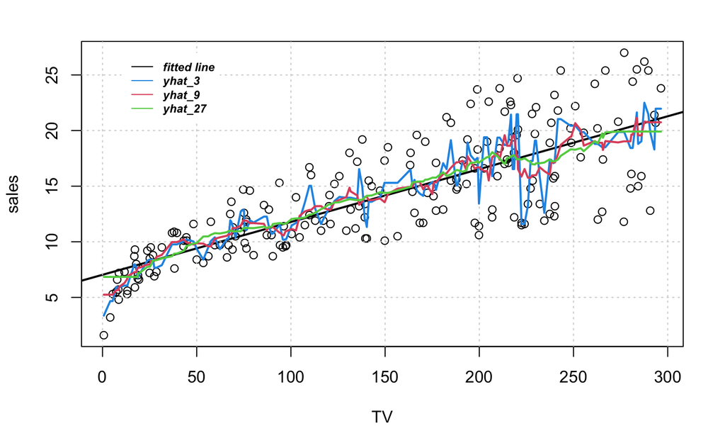

```r
lines(advertising$TV, yhat_27, col=11, lwd=2)
legend(10, 27, legend=c("fitted line", "yhat_3", "yhat_9", "yhat_27"),
       col=c(1, 4, 2, 11), lty=1, cex=0.7, box.lty=0, text.font=4)
```

3. Repeat steps 1 and 2 using `radio` as the predictor.

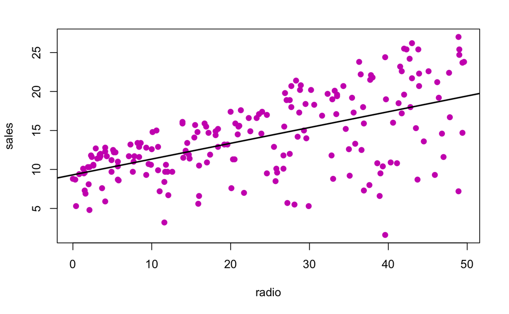

```r
##fit the model
radio.mod <- lm(sales~radio, data=advertising)

##make a scatter plot
plot(sales~radio, data=advertising, pch=19, col=6); abline(radio.mod, col=1, lwd=2)
```

```r
##compute MSE for SLR model (predictor radio)
MSE1 <- mean(radio.mod$residuals^2)

##calculate yhat with the predictor as `radio`
yhat_radio_3 <- myknn(advertising, 'radio', 'sales', 3)
yhat_radio_3
```

```
  [1]  7.600000  7.600000  7.600000  7.800000  8.966667  8.966667  8.800000  8.800000  7.933333  7.733333  7.733333  7.733333  7.733333  9.400000 11.300000 10.900000 10.900000 11.533333 11.866667
 [20] 11.700000 11.700000 11.733333 11.733333 10.433333 10.333333 10.333333 10.333333  9.966667 11.133333 11.133333 11.466667 12.300000 11.033333 10.033333 10.033333 10.033333  9.233333 11.533333
 [39] 11.533333 10.800000 10.800000 10.800000 12.633333 12.633333 12.633333 12.633333 10.933333 10.933333 10.933333 12.666667 12.666667 12.666667 12.600000 10.000000 10.000000 10.000000  7.100000
 [58]  7.100000  7.100000 10.000000  9.000000  9.000000  8.700000 14.500000 14.500000 14.500000 12.666667 12.666667 12.666667 12.233333 12.233333 14.866667 14.866667  9.000000  9.000000  7.566667
 [77]  7.566667 14.100000 14.100000 13.700000 12.500000 12.500000 14.066667 14.066667 14.166667 14.166667 13.100000 14.600000 12.100000 12.100000 10.066667 12.833333 13.900000 15.200000 15.200000
 [96] 16.233333 16.233333 13.400000 12.833333 12.833333 16.100000 16.100000 16.366667 16.366667 14.633333 14.633333 10.500000 10.500000  9.400000  9.400000 12.466667 12.466667 15.133333 15.133333
[115] 14.800000 14.800000 16.300000 16.300000 16.900000 16.900000 13.700000 13.700000 17.633333 17.233333 19.433333 19.433333 15.800000 15.800000 12.566667 13.166667 14.600000 14.600000 18.300000
[134] 16.833333 13.200000 13.200000 13.200000 15.333333 18.700000 18.700000 18.700000 16.166667 16.166667 12.333333 13.666667 15.233333 16.600000 16.600000 19.500000 19.500000 17.566667 13.733333
[153] 13.733333 13.733333 17.200000 17.200000 17.200000 21.800000  8.966667  8.966667  8.833333  7.166667 15.000000 15.000000 15.000000 15.300000 12.566667 17.500000 17.500000 19.633333 21.000000
[172] 21.000000 20.766667 20.766667 23.500000 21.300000 21.300000 21.966667 21.966667 16.466667 18.266667 18.266667 22.800000 22.800000 18.866667 15.166667 16.566667 16.566667 18.333333 15.133333
[191] 15.133333 16.900000 16.900000 19.633333 19.633333 19.100000 19.100000 20.733333 20.733333 20.733333
```

```r
yhat_radio_9 <- myknn(advertising, 'radio', 'sales', 9)
yhat_radio_9
```

```
  [1]  8.400000  8.400000  8.400000  8.400000  8.444444  8.444444  8.544444  8.544444  8.544444  8.733333  8.966667  9.433333  9.433333 10.077778 10.077778 10.200000 10.200000 11.522222 11.100000
 [20] 10.777778 10.777778 10.788889 10.788889 10.822222 10.822222 10.822222 10.822222 10.544444 11.066667 11.066667 10.722222 10.722222 10.722222 10.722222 10.722222 10.722222 10.722222 11.533333
 [39] 12.066667 12.066667 12.066667 12.066667 12.066667 11.755556 11.755556 11.755556 12.077778 12.077778 12.311111 12.066667 12.066667 12.066667 10.766667 10.411111 10.411111 10.188889  8.700000
 [58]  8.700000  8.700000  8.344444  8.344444  8.344444 10.000000 12.722222 12.722222 12.722222 13.211111 13.211111 13.211111 13.211111 13.188889 11.555556 11.555556 12.233333 12.233333 12.177778
 [77] 12.177778 11.822222 11.822222 11.777778 12.811111 14.033333 13.733333 13.733333 13.477778 13.477778 13.344444 13.111111 13.322222 13.322222 13.588889 14.077778 14.077778 12.922222 12.922222
 [96] 12.922222 13.922222 14.322222 15.044444 15.055556 14.522222 15.177778 15.177778 15.177778 12.966667 12.966667 11.666667 11.666667 11.977778 13.022222 13.588889 13.588889 14.522222 14.522222
[115] 14.522222 14.522222 15.000000 15.000000 15.655556 15.655556 16.466667 16.677778 17.011111 16.311111 16.311111 16.311111 16.155556 16.155556 16.611111 16.611111 16.566667 16.511111 15.566667
[134] 16.933333 16.933333 16.933333 17.355556 17.355556 17.355556 16.855556 16.855556 17.011111 16.277778 16.744444 17.055556 17.055556 16.144444 16.455556 16.611111 16.611111 15.366667 15.833333
[153] 16.811111 16.811111 15.322222 15.322222 14.666667 13.722222 12.477778 14.022222 14.022222 12.777778 12.133333 12.133333 12.133333 14.977778 15.733333 18.255556 18.255556 19.866667 20.777778
[172] 20.777778 21.577778 21.577778 22.266667 21.455556 20.511111 20.622222 20.622222 20.277778 19.100000 19.100000 19.100000 19.100000 17.733333 18.111111 16.800000 16.800000 16.800000 16.088889
[191] 16.088889 18.755556 18.755556 20.622222 20.622222 20.622222 20.622222 20.622222 20.622222 20.622222
```

```r
yhat_radio_27 <- myknn(advertising, 'radio', 'sales', 27)
yhat_radio_27
```

```
  [1]  9.755556  9.755556  9.755556  9.755556  9.755556  9.755556  9.755556  9.755556  9.755556  9.755556  9.755556  9.755556  9.755556  9.862963  9.862963  9.862963  9.862963 10.118519 10.233333
 [20] 10.311111 10.311111 10.411111 10.411111 10.644444 10.581481 10.581481 10.581481 10.581481 11.003704 11.003704 10.974074 10.977778 11.081481 11.129630 11.129630 11.129630 11.129630 11.251852
 [39] 11.325926 11.618519 11.618519 11.618519 11.470370 11.077778 11.077778 10.985185 10.777778 10.777778 10.777778 11.055556 11.055556 11.055556 11.211111 11.148148 11.148148 11.248148 11.300000
 [58] 11.300000 11.244444 11.244444 11.337037 11.422222 11.496296 11.200000 11.200000 11.200000 11.340741 11.340741 11.340741 11.607407 11.607407 12.411111 12.411111 12.507407 12.637037 12.637037
 [77] 12.637037 12.955556 12.955556 12.955556 12.785185 12.770370 13.262963 13.262963 13.100000 13.100000 13.162963 13.229630 13.807407 14.207407 14.207407 14.207407 14.207407 14.025926 14.025926
 [96] 14.025926 14.100000 13.803704 13.607407 13.448148 13.662963 13.440741 13.603704 13.885185 13.977778 13.977778 14.622222 14.777778 14.777778 14.777778 14.733333 14.733333 14.733333 14.733333
[115] 14.492593 14.492593 14.492593 14.492593 14.540741 14.540741 14.540741 14.814815 14.814815 14.814815 14.814815 14.814815 15.188889 15.488889 15.488889 15.488889 16.200000 16.192593 16.218519
[134] 16.481481 16.688889 16.607407 16.107407 16.140741 16.140741 16.140741 16.140741 16.714815 16.714815 16.437037 16.437037 16.055556 16.055556 15.677778 14.981481 15.518519 15.518519 15.518519
[153] 15.288889 15.288889 14.837037 14.837037 14.837037 14.755556 15.718519 16.037037 16.037037 16.485185 16.500000 16.500000 16.344444 16.966667 17.018519 17.640741 17.337037 17.337037 17.337037
[172] 17.337037 17.774074 17.774074 17.774074 18.307407 18.307407 18.633333 18.633333 18.640741 18.640741 18.766667 18.766667 18.766667 18.981481 19.255556 19.451852 19.451852 19.451852 19.451852
[191] 19.451852 19.451852 19.451852 19.451852 19.451852 19.451852 19.451852 19.451852 19.451852 19.451852
```

```r
##method 1: calculate MSE using knn.reg()
radio_knn_3 <- knn.reg(advertising$radio, test = data.frame(advertising$radio), y =  advertising$sales, k = 3) #when k=3
MSE_radio_3 <- mean((radio_knn_3$pred - advertising$sales)^2)
MSE_radio_3
```

```
[1] 11.89088
```

```r
radio_knn_9 <- knn.reg(advertising$radio, test = data.frame(advertising$radio), y =  advertising$sales, k = 9) #when k=9
MSE_radio_9 <- mean((radio_knn_9$pred - advertising$sales)^2)
MSE_radio_9
```

```
[1] 15.2745
```

```r
radio_knn_27 <- knn.reg(advertising$radio, test = data.frame(advertising$radio), y =  advertising$sales, k = 27) #when k=27
MSE_radio_27 <- mean((radio_knn_27$pred - advertising$sales)^2)
MSE_radio_27
```

```
[1] 18.20007
```

```r
##method 2: using myknn() to compute MSE
advertising <- arrange(advertising, radio) #sorting

sum((advertising$sales - yhat_radio_3)^2) / n
```

```
[1] 12.09148
```

```r
sum((advertising$sales - yhat_radio_9)^2) / n
```

```
[1] 15.19212
```

```r
sum((advertising$sales - yhat_radio_27)^2) / n
```

```
[1] 18.13235
```

```r
## make a scatter plot
advertising <- arrange(advertising, radio) #sorting
plot(sales~radio, data=advertising); abline(radio.mod, col=1, lwd=2);grid()
lines(advertising$radio, yhat_radio_3, col=4, lwd=2)
```

```r
lines(advertising$radio, yhat_radio_9, col=2, lwd=2)
lines(advertising$radio, yhat_radio_27, col=11, lwd=2)
```

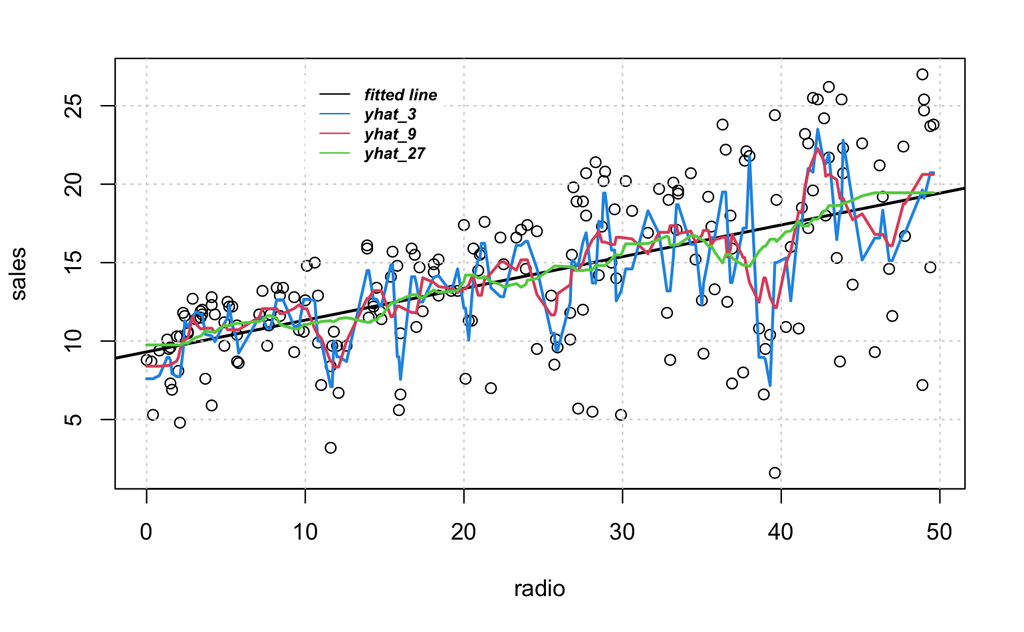

```r
legend(10, 27, legend=c("fitted line", "yhat_3", "yhat_9", "yhat_27"),
       col=c(1, 4, 2, 11), lty=1, cex=0.7, box.lty=0, text.font=4)
```

4. Make a data.frame with the following columns: predictor, k, MSE(SLR), and MSE(KNN). This data.frame should be 6x4 where 6 = [2 predictors (TV or radio)] $\times$ [3 k values (3,9,27)].

```r
## make a data frame
df <- data.frame(predictor = c(rep("TV", 3), rep("radio", 3)),
           k = rep(c(3, 9, 27), 2),
           MSE_SLR = c(rep(MSE, 3), rep(MSE1, 3)),
           MSE_KNN = c(MSE_3, MSE_9, MSE_27, MSE_radio_3, MSE_radio_9, MSE_radio_27))
df
```

| predictor | k | MSE_SLR | MSE_KNN |
| --- | --- | --- | --- |
| TV | 3 | 10.51265 | 6.700078 |
| TV | 9 | 10.51265 | 9.519152 |
| TV | 27 | 10.51265 | 10.371904 |
| radio | 3 | 18.09240 | 11.890883 |
| radio | 9 | 18.09240 | 15.274503 |
| radio | 27 | 18.09240 | 18.200071 |

```r
NA
```

5. Bonus problem (10 points): Modify `myknn()` so that it uses leave-one-out cross-validation (LOOCV). Call the new function `myknn.cv()`. It should return `yhat.cv` = vector of predicted $y$ values based on the leave-one-out approach. You decide how to test `myknn.cv()`.

```r
myknn.cv <- function(dat, name.x, name.y, k) {

dat <- dat[order(dat[,name.x]),]

yhat.cv <- NULL

for(i in 1:nrow(dat)){
x0 <- dat[, name.x][i]
dat$d0 <- abs(dat[,name.x] - x0)
yi <- dat[-i,] %>% arrange(d0) %>% head(k) %>% select(name.y) %>% unlist() %>% mean()
yhat.cv <- c(yhat.cv, yi)

}
return(yhat.cv)
}

##testing
myknn.cv(advertising, 'TV', 'sales', 5)
```

```
  [1]  5.26  4.94  5.16  5.92  5.70  5.88  6.46  5.98  5.72  7.36  7.30  7.38  7.94  7.26  7.52  7.02  6.96  7.04  6.84  8.18  8.58  8.32  8.12  7.88  8.26  8.64  8.66  9.68  9.78 10.44  9.80  9.80
 [33]  9.70 10.44 10.50  9.42  9.78 10.04  9.54  8.92  9.38 10.46 11.28 11.06 10.50 10.66 11.52 11.12 11.52 11.80 11.34 11.46 11.72 12.00 11.00 11.52 11.04 10.38 11.54 10.32 12.16 11.70 12.16 11.82
 [65]  9.78 11.10 11.14 10.76 10.20 10.18 11.02 10.38 13.06 13.90 13.30 12.44 12.70 13.60 12.56 12.38 12.78 12.58 14.08 13.36 14.00 15.04 13.10 14.12 16.10 13.74 14.64 11.88 13.74 13.50 14.12 14.12
 [97] 12.24 12.34 15.28 13.74 15.18 13.50 16.16 15.28 15.06 15.76 16.14 13.70 15.48 15.46 13.36 14.28 15.48 15.64 14.68 13.82 17.46 15.88 17.42 16.38 16.62 16.80 16.76 15.92 17.44 16.64 17.28 18.32
[129] 17.34 13.72 14.80 16.34 16.18 16.38 14.98 15.32 17.76 17.62 16.86 18.26 18.08 19.68 18.74 20.14 20.20 18.84 17.86 18.94 19.64 20.80 18.88 16.28 15.94 17.54 17.50 14.30 14.98 18.44 17.10 18.30
[161] 17.46 16.98 18.14 17.52 18.16 16.88 16.52 17.06 17.74 15.56 17.78 17.24 18.00 17.28 21.18 21.04 20.38 21.06 20.62 17.54 18.34 19.98 19.84 18.90 17.30 19.02 20.62 17.58 20.96 21.34 19.68 17.24
[193] 21.62 23.30 18.92 19.40 21.92 21.78 21.92 21.30
```